# Charlotte Hornets Data Analysis

Jack Funk

#### Step 0: Install and load packages

I am using the tidyverse, lubridate, ggplot2, and dplyr packages.

```r
install.packages("tidyverse",dependencies = TRUE)
install.packages("lubridate",dependencies = TRUE)
install.packages("ggplot2",dependencies = TRUE)
install.packages("dplyr", dependencies = TRUE)
```

```r
library(tidyverse)
library(lubridate)
```

#### Step 1: Collect Data

I used a dataset from Kaggle containing data from NBA games. I downloaded the .csv and read it to the game dataframe

```r
game <- read_csv("game.csv")
```

#### Step 2: Clean dataframe for hornets

In this step, I removed all data from before the 2003-2004 season. This season was the first season of the Charlotte Bobcats. For this analysis, I am considering the New Orleans Hornets/Pelicans a separate franchise.I also remove columns I will not need for this analysis.

```r
game_cha <- na.omit(game[!(game$game_date < "2003-07-01" | (game$team_abbreviation_home != "CHA" & game$team_abbreviation_away != "CHA")),])

game_cha <- game_cha %>%
  select(-c(team_id_home, team_name_home, matchup_home, video_available_home, team_id_away, team_name_away, matchup_away, video_available_away))
```

#### Step 3: Split home and away dataframes

In this step, I am splitting the datasets into “Hornets Home Games” and “Hornets Away Games”

```r
game_home_cha <- game_cha[!(game_cha$team_abbreviation_home != "CHA"),]

game_away_cha <- game_cha[!(game_cha$team_abbreviation_away != "CHA"),]
```

#### Step 4: Create the Hornets dataframe

In this step, I remove all data for Charlotte’s opponents from the Home and Away dataframes. I rename the columns to make them consistent, and then I recombine them to form one dataframe.

```r
# Remove other team data
game_home_cha_only <- game_home_cha %>%
  select(-c(team_abbreviation_away, wl_away, fgm_away, fga_away, fg_pct_away, fg3m_away, fg3a_away, fg3_pct_away, ftm_away, fta_away, ft_pct_away, oreb_away, dreb_away, reb_away, ast_away, stl_away, blk_away, tov_away, pf_away, pts_away, plus_minus_away))

# Remove other team data
game_away_cha_only <- game_away_cha %>%
  select(-c(team_abbreviation_home, wl_home, fgm_home, fga_home, fg_pct_home, fg3m_home, fg3a_home, fg3_pct_home, ftm_home, fta_home, ft_pct_home, oreb_home, dreb_home, reb_home, ast_home, stl_home, blk_home, tov_home, pf_home, pts_home, plus_minus_home))

#Rename columns to build CHA stat dataframe
game_home_cha_only <- game_home_cha_only %>% rename(team_abbreviation = team_abbreviation_home, wl = wl_home, fgm = fgm_home, fga = fga_home, fg_pct = fg_pct_home, fg3m = fg3m_home, fg3a = fg3a_home, fg3_pct = fg3_pct_home, ftm = ftm_home, fta = fta_home, ft_pct = ft_pct_home, oreb = oreb_home, dreb = dreb_home, reb = reb_home, ast = ast_home, stl = stl_home, blk = blk_home, tov = tov_home, pf = pf_home, pts = pts_home, plus_minus = plus_minus_home)

#Rename columns to build CHA stat dataframe
game_away_cha_only <- game_away_cha_only %>% rename(team_abbreviation = team_abbreviation_away, wl = wl_away, fgm = fgm_away, fga = fga_away, fg_pct = fg_pct_away, fg3m = fg3m_away, fg3a = fg3a_away, fg3_pct = fg3_pct_away, ftm = ftm_away, fta = fta_away, ft_pct = ft_pct_away, oreb = oreb_away, dreb = dreb_away, reb = reb_away, ast = ast_away, stl = stl_away, blk = blk_away, tov = tov_away, pf = pf_away, pts = pts_away, plus_minus = plus_minus_away)

# Stack home and away frames into one frame
complete_cha_stats <- bind_rows(game_home_cha_only, game_away_cha_only)
```

#### Step 5: Create Opponents dataframe

In this step, I do the same transformations from Step 4 to create an Opponents dataframe

```r
# Remove CHA data
game_home_opp_only <- game_home_cha %>%
  select(-c(team_abbreviation_home, wl_home, fgm_home, fga_home, fg_pct_home, fg3m_home, fg3a_home, fg3_pct_home, ftm_home, fta_home, ft_pct_home, oreb_home, dreb_home, reb_home, ast_home, stl_home, blk_home, tov_home, pf_home, pts_home, plus_minus_home))

# Remove CHA data
game_away_opp_only <- game_away_cha %>%
  select(-c(team_abbreviation_away, wl_away, fgm_away, fga_away, fg_pct_away, fg3m_away, fg3a_away, fg3_pct_away, ftm_away, fta_away, ft_pct_away, oreb_away, dreb_away, reb_away, ast_away, stl_away, blk_away, tov_away, pf_away, pts_away, plus_minus_away))

#Rename columns to build opponent stat dataframe
game_away_opp_only <- game_away_opp_only %>% rename(team_abbreviation = team_abbreviation_home, wl = wl_home, fgm = fgm_home, fga = fga_home, fg_pct = fg_pct_home, fg3m = fg3m_home, fg3a = fg3a_home, fg3_pct = fg3_pct_home, ftm = ftm_home, fta = fta_home, ft_pct = ft_pct_home, oreb = oreb_home, dreb = dreb_home, reb = reb_home, ast = ast_home, stl = stl_home, blk = blk_home, tov = tov_home, pf = pf_home, pts = pts_home, plus_minus = plus_minus_home)

#Rename columns to build opponent stat dataframe
game_home_opp_only <- game_home_opp_only %>% rename(team_abbreviation = team_abbreviation_away, wl = wl_away, fgm = fgm_away, fga = fga_away, fg_pct = fg_pct_away, fg3m = fg3m_away, fg3a = fg3a_away, fg3_pct = fg3_pct_away, ftm = ftm_away, fta = fta_away, ft_pct = ft_pct_away, oreb = oreb_away, dreb = dreb_away, reb = reb_away, ast = ast_away, stl = stl_away, blk = blk_away, tov = tov_away, pf = pf_away, pts = pts_away, plus_minus = plus_minus_away)

# Stack home and away frames into one frame
complete_opp_stats <- bind_rows(game_home_opp_only, game_away_opp_only)
```

#### Step 6: Create Others dataframe

```r
game_others <- na.omit(game[!(game$game_date < "2003-07-01" | (game$team_abbreviation_home == "CHA" & game$team_abbreviation_away == "CHA")),])

game_others <- game_others %>%
  select(-c(team_id_home, team_name_home, matchup_home, video_available_home, team_id_away, team_name_away, matchup_away, video_available_away))

# Create others home dataframe
game_home_others <- game_others %>%
  select(-c(team_abbreviation_away, wl_away, fgm_away, fga_away, fg_pct_away, fg3m_away, fg3a_away, fg3_pct_away, ftm_away, fta_away, ft_pct_away, oreb_away, dreb_away, reb_away, ast_away, stl_away, blk_away, tov_away, pf_away, pts_away, plus_minus_away))

# Remove other team data
game_away_others <- game_others %>%
  select(-c(team_abbreviation_home, wl_home, fgm_home, fga_home, fg_pct_home, fg3m_home, fg3a_home, fg3_pct_home, ftm_home, fta_home, ft_pct_home, oreb_home, dreb_home, reb_home, ast_home, stl_home, blk_home, tov_home, pf_home, pts_home, plus_minus_home))

#Rename columns to build others stat dataframe
game_home_others <- game_home_others %>% rename(team_abbreviation = team_abbreviation_home, wl = wl_home, fgm = fgm_home, fga = fga_home, fg_pct = fg_pct_home, fg3m = fg3m_home, fg3a = fg3a_home, fg3_pct = fg3_pct_home, ftm = ftm_home, fta = fta_home, ft_pct = ft_pct_home, oreb = oreb_home, dreb = dreb_home, reb = reb_home, ast = ast_home, stl = stl_home, blk = blk_home, tov = tov_home, pf = pf_home, pts = pts_home, plus_minus = plus_minus_home)

#Rename columns to build others stat dataframe
game_away_others <- game_away_others %>% rename(team_abbreviation = team_abbreviation_away, wl = wl_away, fgm = fgm_away, fga = fga_away, fg_pct = fg_pct_away, fg3m = fg3m_away, fg3a = fg3a_away, fg3_pct = fg3_pct_away, ftm = ftm_away, fta = fta_away, ft_pct = ft_pct_away, oreb = oreb_away, dreb = dreb_away, reb = reb_away, ast = ast_away, stl = stl_away, blk = blk_away, tov = tov_away, pf = pf_away, pts = pts_away, plus_minus = plus_minus_away)

# Stack home and away frames into one frame
complete_others_stats <- bind_rows(game_home_others, game_away_others)
```

#### Step 8: Recombine dataframes

```r
game_stats <- bind_rows(complete_cha_stats, complete_opp_stats, complete_others_stats)
```

#### Step 9: Create Visualizations

In this step, I create several visualizations to show insights about the data

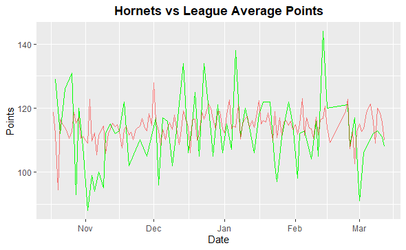

```r
#Points
ggplot() +
  geom_line(data=subset(complete_cha_stats, season_id == 22022), aes(x=game_date, y=pts, group=1), color='green', alpha = 1) +
  geom_line(data=subset(others_summ, season_id == 22022), aes(x=game_date, y=pts, group=2), color='red', alpha = 0.5) +
  labs(title = "Hornets vs League Average Points", x = "Date", y = "Points") +
  theme(plot.title = element_text(face = "bold", hjust = .5))
```

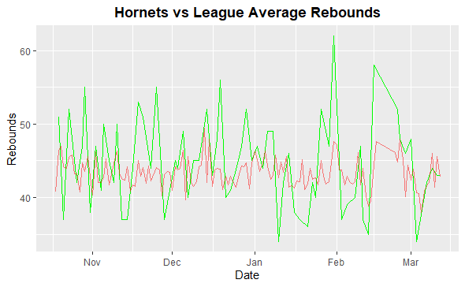

```r
#Rebounds
ggplot() +
  geom_line(data=subset(complete_cha_stats, season_id == 22022), aes(x=game_date, y=reb, group=1), color='green', alpha = 1) +
  geom_line(data=subset(others_summ, season_id == 22022), aes(x=game_date, y=reb, group=2), color='red', alpha = 0.5) +
  labs(title = "Hornets vs League Average Rebounds", x = "Date", y = "Rebounds") +
  theme(plot.title = element_text(face = "bold", hjust = .5))
```

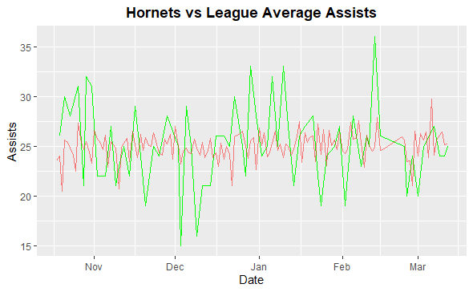

```r
#Assists
ggplot() +
  geom_line(data=subset(complete_cha_stats, season_id == 22022), aes(x=game_date, y=ast, group=1), color='green', alpha = 1) +
  geom_line(data=subset(others_summ, season_id == 22022), aes(x=game_date, y=ast, group=2), color='red', alpha = 0.5) +
  labs(title = "Hornets vs League Average Assists", x = "Date", y = "Assists") +
  theme(plot.title = element_text(face = "bold", hjust = .5))
```

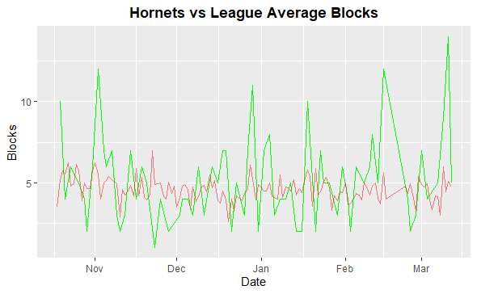

```r
#Blocks
ggplot() +
  geom_line(data=subset(complete_cha_stats, season_id == 22022), aes(x=game_date, y=blk, group=1), color='green', alpha = 1) +
  geom_line(data=subset(others_summ, season_id == 22022), aes(x=game_date, y=blk, group=2), color='red', alpha = 0.5) +
  labs(title = "Hornets vs League Average Blocks", x = "Date", y = "Blocks") +
  theme(plot.title = element_text(face = "bold", hjust = .5))
```

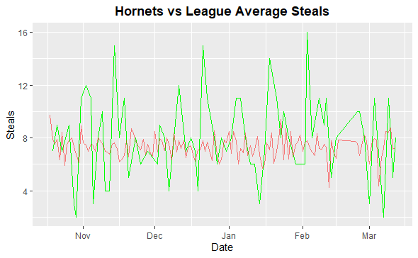

```r
#Steals
ggplot() +
  geom_line(data=subset(complete_cha_stats, season_id == 22022), aes(x=game_date, y=stl, group=1), color='green', alpha = 1) +
  geom_line(data=subset(others_summ, season_id == 22022), aes(x=game_date, y=stl, group=2), color='red', alpha = 0.5) +
  labs(title = "Hornets vs League Average Steals", x = "Date", y = "Steals") +
  theme(plot.title = element_text(face = "bold", hjust = .5))
```

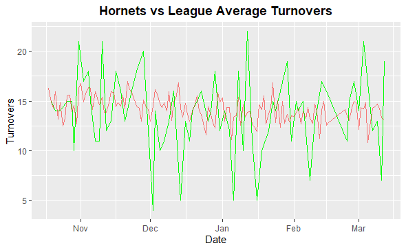

```r
#Turnovers
ggplot() +
  geom_line(data=subset(complete_cha_stats, season_id == 22022), aes(x=game_date, y=tov, group=1), color='green', alpha = 1) +
  geom_line(data=subset(others_summ, season_id == 22022), aes(x=game_date, y=tov, group=2), color='red', alpha = 0.5) +
  labs(title = "Hornets vs League Average Turnovers", x = "Date", y = "Turnovers") +
  theme(plot.title = element_text(face = "bold", hjust = .5))
```